# Geocode Checking Protocol

InSpace

11/13/2022

# InSpace – Geocoding Protocol

*Important NOTE: do not put any participant addresses into google maps. Google is a third party and you are providing them with identifiable participant information when you enter an address*

Ensuring the most precise geocoding of participant addresses will enable you to pull the most accurate measures of the environmental context. While the ACMT has a built-in geocoder, we are also relying on our partners to verify that the geocodes produced by the ACMT accurately represent the location of the participant.

This exercise of cleaning up addresses and checking geocodes can benefit from local knowledge of the area in which your participants reside. It may be beneficial to talk to someone else in your lab (who is on the IRB for your project) to help identify potential address and/or geocoding errors.

The process of verifying participant locations is an iterative process of mapping geocodes, updating addresses, re-mapping, and noting where location are inaccurate, even after address updates. This process utilizes the ACMT map checking and geocoder functions to produce maps, geocodes, and ratings of the geocodes.

This tool can be helpful in verifying zip codes in your area: https://www.unitedstateszipcodes.org/

## Import address data & combine address fields if necessary

- You will first need to upload your datatset into your Inspace folder, import that data into the R environment, and update using the provided code so that your data is formatted as follows, with an id field with the record id and an address field with the full address:

| id | address |
| --- | --- |
| 5 | 1245 First Ave, Seattle, WA, 98564 |
| 18 | 6789 Second Street, Seattle, WA, 98564 |
| 89 | 999 MLK Way, Seattle, WA, 98564 |
| .. | …. |

## Run Mapping function loop to map all addresses

Next, use the code provided in the Mapping Geocodes - Code file to geocode the addresses to get the lat / long values for each individual in the dataset.

The provided code will create two documents for you to reference as you check the geocode locations: (1) A pdf file with a map printed for each individual in your dataset (2) A csv file with ratings, address, and a notes columns.

You’ll find these documents in your Inspace folder after running the code in Step 3 of the Mapping Geocodes document. Export them and use them to review the maps.

Running the geocode loop will also produce a table of your initial geocode ratings. This will give you a sense of how many addresses will require follow-up review (i.e., all ratings >0)

## Check the mapped geocodes

- Once you have geocoded your data and exported the dataset_address_check document, open the file in excel. You can work off of this file as you check geolocations and make notes about addresses that have high ratings, but look accurate.

**For each address with rating >0, take the following steps:** *NOTE: Do not put any participant addresses into google maps. If you need to check the address, you can put the street name into google maps, but do not include the house number*

1. Update the address to write out any ‘Ave’ to ‘Avenue’, ‘S’ to ‘South’, etc.
2. Check the zip code for the given city and/or cross street. This website: https://www.unitedstateszipcodes.org/ is a helpful tool for locating zip codes in your area.
3. Increase/Decrease the level of detail by changing the ‘z’ value (higher numbers here give more detailed maps, but may not be available for more rural areas - you can lower the number to 14 or 15 if the map is blank)
4. Increase/Decrease the level of zoom by changing the ‘side_len’ value (higher numbers give a larger map, but may take longer to load (I recommend not going higher than 0.05))
5. If the street name is not appearing on the map after the above edits, you can search the street name or nearby cross streets in google maps to pinpoint the geocoded location and ensure the geocode is mapping to the correct street (DO NOT PUT THE FULL ADDRESS IN GOOGLE MAPS)
6. If you are unsure if the location is correct or not based off of the map, and the rating is still >0 after edits, leave the comment field blank and move on to the next address (this geocode will be assummed inaccurate)

**After each step, you can use the code below to make the updates to the dataset directly in R and to re-geocode and re-map the updated location.**

```r
## enter the id number for the participant whose address you are updating here:
i<- 8 #
## enter the updated address text for the individual here:
update.address<- '3528 S Ferdinand St., Seattle, WA, 98118'
## change the level of detail of the map:
z<-17# #higher numbers here give more detailed maps, but may not be available for more rural areas - you can lower the number to 14 or 15 if the map is blank.
## change the zoom level of the map:
side_len<-0.003 # higher numbers give a larger map, but may take longer to load (I recommend not going higher than 0.05)


#update the address in the dataset for the given id
dataset_geocode$address[dataset_geocode$id==i]<-update.address
dataset_geocode$address[dataset_geocode$id==i]
```

```
## [1] "3528 S Ferdinand St., Seattle, WA, 98118"
```

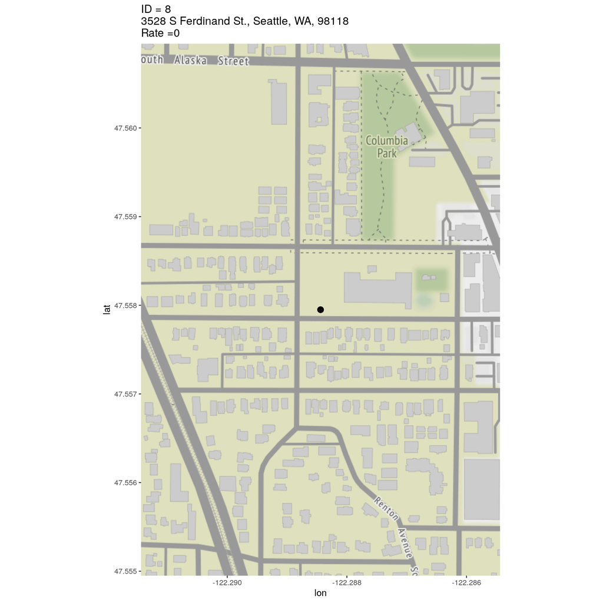

```r
## get updated geocodes and put the updated geocode and rating into the dataset:
address<-dataset_geocode$address[dataset_geocode$id==i]
lat_long<-tryCatch({geocode(address)},
                     error=function(x){
                       lat_long<-list(latitude=NA, longitude=NA, rating=NA)
                       })
  dataset_geocode$lat[dataset_geocode$id==i]<-lat_long$latitude # add latitude to dataset_geocode
  dataset_geocode$long[dataset_geocode$id==i] <-lat_long$longitude # add longitude to dataset_geocode
  dataset_geocode$rating[dataset_geocode$id==i]<-lat_long$rating # add rating to the dataset_geocode


## reprint the updated geocode
check_geocode(lat=dataset_geocode$lat[dataset_geocode$id==i], long=dataset_geocode$long[dataset_geocode$id==i], address=dataset_geocode$address[dataset_geocode$id==i], rate=dataset_geocode$rating[dataset_geocode$id==i], id=i,
              z=z, ##higher numbers here give more detailed maps, but may not be available for more rural areas - you can lower the number to 14 or 15 if the map is blank.
              side_len=side_len # higher numbers give a larger map, but may take longer to load (I recommend not going higher than 0.05)
              )
```

```r
## if the reprinted map still looks incorrect, make additional edits to the address and rerun the code.
```

## Export final geocoded dataset to Inspace folder

Once each address has been checked and updates have been made as needed, export your final geocoded dataset to your Inspace folder. This is the dataset that will be used for pulling environmental measures.

In the ‘dataset_address_check.csv’ file, remove the address column, and save the excel file with your notes. This will be shared with the Inspace team so they can reference it for geocodes with high ratings.